# Marketing Campaign EDA

###### Cheking MntMeatProducts column

```python
df.MntMeatProducts.sum()
```

```
370045
```

```python
np.round((df.MntMeatProducts.sum() / df.total_spent.sum() * 100),2)
```

```
27.51
```

Insight:

27% of spending went to meat products.

###### Checking MntFishProducts column

```python
df.MntFishProducts.sum()
```

```
83397
```

```python
np.round((df.MntFishProducts.sum() / df.total_spent.sum() * 100),2)
```

```
6.2
```

Insight:

6% of spending went to fish products.

###### Checking MntSweetProducts column

```python
df.MntSweetProducts.sum()
```

```
59895
```

```python
np.round((df.MntSweetProducts.sum() / df.total_spent.sum() * 100),2)
```

```
4.45
```

Insight:

4% of spending went to Sweet products.

###### Checking MntGoldProds column

```python
df.MntGoldProds.sum()
```

```
97415
```

```python
np.round((df.MntGoldProds.sum() / df.total_spent.sum() * 100),2)
```

```
7.24
```

Insight:

7% of spending went to Gold products

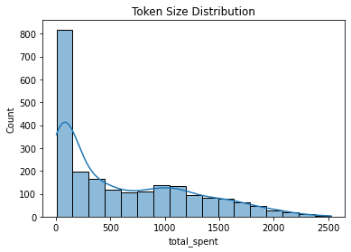

```python
sns.histplot(df.total_spent,kde=True)
plt.title('Token Size Distribution')
plt.show()
```

Insight:

As expected people who spend more are less than people who spend less.

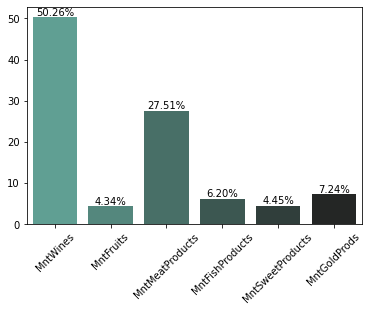

```python
ax = sns.barplot(x = (df[df.columns[df.columns.str.match("Mnt")]].sum() / df.total_spent.sum() * 100).index,
            y = (df[df.columns[df.columns.str.match("Mnt")]].sum() / df.total_spent.sum() * 100).values,
            ci = None,palette="dark:#5A9_r")
for i in ax.containers :
    plt.bar_label(i, fmt = "%.2f%%")
plt.xticks(rotation = 45);
```

###### Checking AcceptedCmp1_new column

```python
df.AcceptedCmp1_new.value_counts()
```

```
No     2073
Yes     142
Name: AcceptedCmp1_new, dtype: int64
```

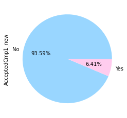

```python
df.AcceptedCmp1_new.value_counts().plot.pie(autopct='%.2f%%',colors = ["#99d6ff","#ffccee"])
plt.show()
```

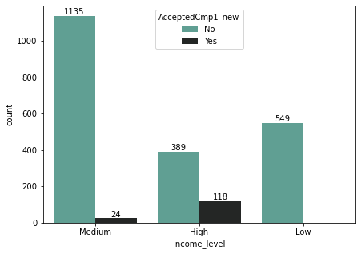

```python
plt.figure(figsize=(7,5))
ax = sns.countplot(x = df.Income_level, hue = df.AcceptedCmp1_new,palette="dark:#5A9_r")
for i in ax.containers :
    plt.bar_label(i)
plt.show()
```

Insights:

1. 6.41% of customers accepted campaign 1.
2. People from high income level have shown high interest in this campaign as compared to people with medium income level.
3. Customers of low income level has shown no interest in this campaign.

###### Checking AcceptedCmp2_new column

```python
df.AcceptedCmp2_new.value_counts()
```

```
No     2185
Yes      30
Name: AcceptedCmp2_new, dtype: int64
```

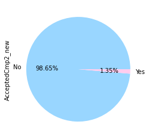

```python
df.AcceptedCmp2_new.value_counts().plot.pie(autopct='%.2f%%',colors = ["#99d6ff","#ffccee"])
plt.show()
```

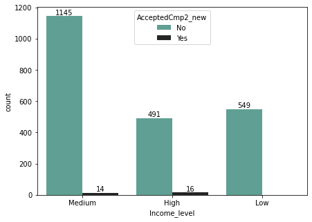

```python
plt.figure(figsize=(7,5))
ax = sns.countplot(x = df.Income_level, hue = df.AcceptedCmp2_new,palette="dark:#5A9_r")
for i in ax.containers :
    plt.bar_label(i)
plt.show()
```

Insights:

1. 1.35% of customers accepted campaign 2.
2. Customers from all income level has not shown much interest.

###### Checking AcceptedCmp3_new column

```python
df.AcceptedCmp3_new.value_counts()
```

```
No     2052
Yes     163
Name: AcceptedCmp3_new, dtype: int64
```

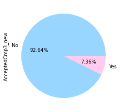

```python
df.AcceptedCmp3_new.value_counts().plot.pie(autopct='%.2f%%',colors = ["#99d6ff","#ffccee"])
plt.show()
```

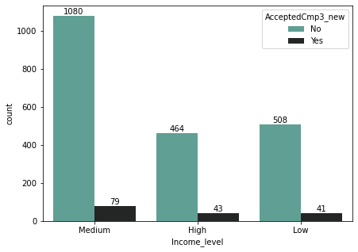

```python
plt.figure(figsize=(7,5))
ax = sns.countplot(x = df.Income_level, hue = df.AcceptedCmp3_new,palette="dark:#5A9_r")
for i in ax.containers :
    plt.bar_label(i)
plt.show()
```

Insights:

1. 7.36% of customers accepted campaign 3.
2. Customers from medium income level has shown higher interest.
3. Customers from High and low income level has shown equal interest.

###### Checking AcceptedCmp4_new column

```python
df.AcceptedCmp4_new.value_counts()
```

```
No     2051
Yes     164
Name: AcceptedCmp4_new, dtype: int64
```

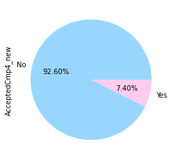

```python
df.AcceptedCmp4_new.value_counts().plot.pie(autopct='%.2f%%',colors = ["#99d6ff","#ffccee"])
plt.show()
```

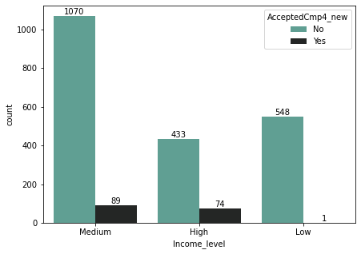

```python
plt.figure(figsize=(7,5))
ax = sns.countplot(x = df.Income_level, hue = df.AcceptedCmp4_new,palette="dark:#5A9_r")
for i in ax.containers :
    plt.bar_label(i)
plt.show()
```

Insights:

1. 7.40% of customers accepted campaign 4.
2. Customers from High and medium income level has shown higher interest.

###### Checking AcceptedCmp5_new column

```python
df.AcceptedCmp5_new.value_counts()
```

```
No     2053
Yes     162
Name: AcceptedCmp5_new, dtype: int64
```

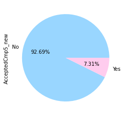

```python
df.AcceptedCmp5_new.value_counts().plot.pie(autopct='%.2f%%',colors = ["#99d6ff","#ffccee"])
plt.show()
```

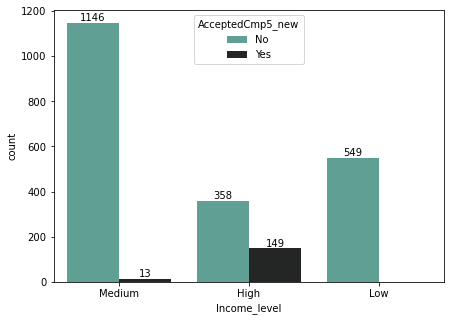

```python
plt.figure(figsize=(7,5))
ax = sns.countplot(x = df.Income_level, hue = df.AcceptedCmp5_new,palette="dark:#5A9_r")
for i in ax.containers :
    plt.bar_label(i)
plt.show()
```

Insights:

1. 7.31% of customers accepted campaign 5.
2. Customers from High income level has shown higher interest.
3. Customers from Medium income level has shown very low interest and low income level customers has not participated at all.

###### Checking AcceptedCmp6_new column

```python
df.AcceptedCmp6_new.value_counts()
```

```
No     1882
Yes     333
Name: AcceptedCmp6_new, dtype: int64
```

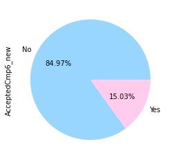

```python
df.AcceptedCmp6_new.value_counts().plot.pie(autopct='%.2f%%',colors = ["#99d6ff","#ffccee"])
plt.show()
```

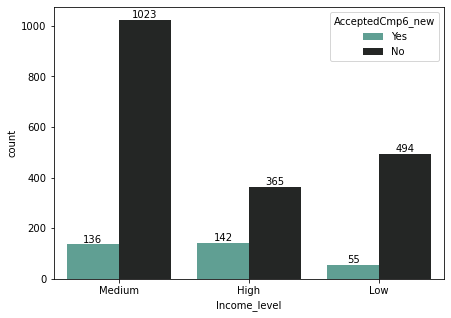

```python
plt.figure(figsize=(7,5))
ax = sns.countplot(x = df.Income_level, hue = df.AcceptedCmp6_new,palette="dark:#5A9_r")
for i in ax.containers :
    plt.bar_label(i)
plt.show()
```

Insight:

1. 15.03% of customers accepted campaign 6.
2. Customers of all income levels showed interest best campaign so far.

## Conclusion

1. Most of the customers belong to medium Income level i.e. Income between 35000-70000.
2. Customers with no child have higher average income.
3. People who earn more are likely to spend more.
4. People with high income level purchase Liquor and meat products more than any other income level.
5. 50% customers have education level Graduation.
6. Basic education level stands out at low income level.
7. The low level of education is reflected in the income level.
8. Customer satistfaction is very high only 0.95% complains.
9. Complainers have slightly lower income level.
10. Most of the customers are married.
11. Average income in all marital status are close.
12. In all income levels we have almost same ratio of people belonging to different marital statuses.
13. 50% of total spend by customers are spent on Wines category which is highest and second highest is meat category with 27% of total spend by customers.
14. Sweets and Fruits category has lowest percentage in total spend by customers about 4% each.
15. Medium level income customers like to purchase when discounts are there.
16. Catalog purchases are almost equally done by high and medium income level customers.
17. Maximum web and store purchases are done by Medium income level customers.
18. Married customers are also more likely to purchase from web and stores.
19. Campaign 2 was worst campaign only 1.35% of customers accepted it.
20. Last campaign i.e. campaign 6 is most sucessful campaign 15.03% customers accepted it and customers from all income level showed interest in it.